# Developing a Research Topic

14.33 Research and Communication in Economics

Jon Cohen

September 14, 2026

## Agenda

1. Respond to syllabus feedback and reiterate AI disclosure policy
2. Recap of previous lecture: Research topic as question + setting + data
3. Recap of causal inference
4. Examples of topics motivated by question vs. setting vs. data
5. Advice on spotting questions, settings, and data

## Recap: question + setting + data

- **Question:** what your paper will answer
  - Motivated by economic theory or a policy issue
- **Setting:** institutional details that enable a causal comparison or test of a theory
- **Data:** measurements used to answer the question in the setting
- You will iterate among these components as you learn more about each one
- Examples last time: housing development (causal) and private information in insurance (descriptive)

## Recap of causal inference

## Causal inference basics

- A causal **question** asks what *would* happen to outcome $Y$ if treatment $D$ changed
- In the **data**, we can observe only what *actually* happens for each unit $i$
- We address the missing counterfactual with assumptions based on institutional knowledge of the **setting**
  - Free, detailed, and approachable online textbook: [Causal Inference: The Mixtape](https://mixtape.scunning.com/)
  - Animated visualizations of some approaches: [Nick Huntington-Klein’s website](https://nickchk.com/causalgraphs.html)

## The fundamental problem of causal inference

- Notation: potential outcomes for unit $i$ (at time $t$) are $Y_i(1)$ when $D_i=1$, $Y_i(0)$ when $D_i=0$

| Realized treatment | $Y_i(1)$ | $Y_i(0)$ |
| --- | --- | --- |
| $D_i=1$ | Observed | Missing |
| $D_i=0$ | Missing | Observed |

- Problem: We cannot identify the individual causal effect $Y_i(1)-Y_i(0)$
- Solution: An identification strategy states the assumptions that let us learn a causal effect from observed data

## Selected strategies for identifying causal effects

1. Randomized controlled trial
2. Selection on observables
3. Instrumental variables
4. Regression discontinuity
5. Bunching
6. Difference-in-differences

## Randomized controlled trial

[figure not shown]

- Random assignment makes the groups comparable on average
- The untreated-group mean estimates the treated group’s counterfactual mean

## Observational data: what else determines treatment?

[figure not shown]

- $D$ and $Y$ may share unobserved causes, $U$
- Association combines the causal path with $D \leftarrow U \rightarrow Y$

## Exercise: interrogating causal relationships

[The Economist, “Is AI putting graduates out of work already?”](https://www.economist.com/finance-and-economics/2026/05/13/is-ai-putting-graduates-out-of-work-already)

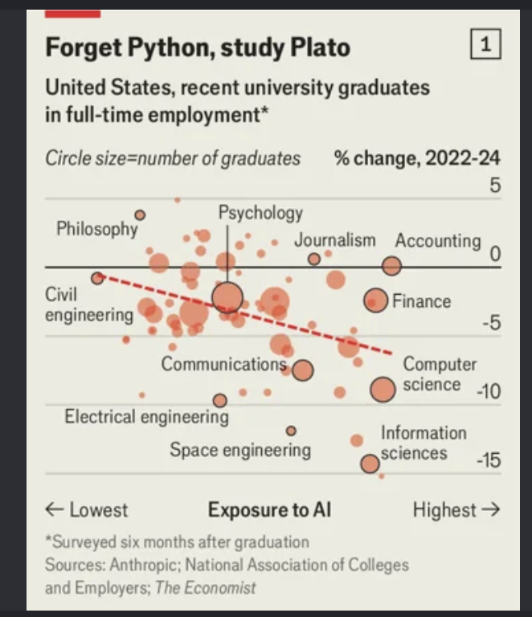

- State the causal relationship that the graph’s title implies.
- State alternative causal explanations consistent with the data.

## Observational design #1: selection on observables

[figure not shown]

- Compare treated and untreated units with the same pre-treatment $X$
- Assumption: comparing within $X$ blocks the confounding “backdoor” path from $D$ to $Y$

## A control is not automatically enough

[figure not shown]

*Key question:* Why is variation in $D$ as good as random within $X$?

## Advice: pursuing selection on observables

- Setting as motivation: treatment is assigned systematically but you observe the relevant inputs
  - [Abdulkadiroğlu, Angrist, Narita, and Pathak (2017)](https://doi.org/10.3982/ECTA12917): centralized school assignment uses priorities and preferences that the researcher observes
  - [Borusyak and Hull (2023)](https://onlinelibrary.wiley.com/doi/abs/10.3982/ECTA19367): Chinese high-speed rail proposals had equally-suitable connections but only some were built
- Data as motivation: language models can represent high-dimensional, nonstandard data
  - [Bajari et al. (2025)](https://arxiv.org/abs/2305.00044): encode product text and images as quality controls in a hedonic price index

## Observational design #2: instrumental variables

[figure not shown]

- Focus on the variation in $D$ induced by $Z$
- Assumptions:
  1. First stage: $Z$ changes $D$
  2. Independence: $Z$ and $Y$ have no common causes
  3. Exclusion: $Z$ affects $Y$ only through $D$

## Advice: pursuing instruments

- Setting as motivation: know one specific observable factor that changes treatment
  - [Geography](https://www.aeaweb.org/articles?id=10.1257/aer.89.3.379), [weather](https://academic.oup.com/qje/article-abstract/128/4/1633/1849540), or [institutional quirks](https://academic.oup.com/qje/article-abstract/106/4/979/1873496)
  - [Decision-makers with different tendencies](https://arxiv.org/abs/2511.03572), with as-if-random assignment to the decision-maker

[Cunningham, “Five Common Distinct IV Designs”](https://mixtape.scunning.com/07-instrumental_variables#five-common-distinct-iv-designs)

## Observational design #3: regression discontinuity

$$D_i = 1[X_i \geq c]$$

$$\tau_{RDD} = \lim_{x \downarrow c} E[Y_i \mid X_i=x]
- \lim_{x \uparrow c} E[Y_i \mid X_i=x]$$

- Treatment changes at cutoff $c$
- Assumption: average untreated potential outcomes are continuous at $c$

## Advice: pursuing regression discontinuity

- Setting as motivation: find a stark cutoff rule that changes treatment
  - [Lee (2008)](https://doi.org/10.1257/aer.98.3.808): narrowly winning an election changes whether a party holds office
- Learn exactly how the running variable and cutoff determine treatment
- Ask whether units can sort around the cutoff or whether other rules change there

## Exercise: a tax notch and a regression discontinuity

Los Angeles’ mansion tax has a sharp notch: no tax below a $5.4 million sale price and a 4% tax on the full price above it.

**3 minutes:** Is the threshold a useful cutoff for an RDD?

## Observational design #4: bunching

- If people can sort around a threshold, an RDD comparison is not clean
- Make lemons into lemonade: the sorting itself is informative
- Infer the smooth **counterfactual density** without the notch
- **Bunching:** use excess mass near the cutoff to measure behavioral responses

## Observational design #5: difference-in-differences

- Observe treated and untreated groups before and after treatment begins
- Group levels may differ before treatment
- Use the untreated group’s change to infer the treated group’s counterfactual change

## Difference-in-differences: what we observe

[figure not shown]

## Difference-in-differences: infer the missing trend

[figure not shown]

**Parallel trends assumption:** the untreated potential outcomes of both groups change similarly, even if their levels are different

## Advice: pursuing difference-in-differences

- Setting as motivation: a policy changes for some groups but not others or rolls out gradually
- Similar pre-treatment trends are useful evidence, not proof
- Institutional knowledge must support the comparison group and timing

## Forming a research topic

## Economics is a broad field

- Be creative in seeing economic concepts
- [Examples of economic research across a variety of fields](https://docs.google.com/document/d/15kgn_m3mmpEQ9fvd0C6rSTc6gKXV99-SuPFjlrpiqGE/)

## Three ways to start

- Research is a nonlinear and iterative process
- The following slides highlight papers that plausibly came from different starting points:
  - **Question-led:** something you want to understand
  - **Setting-led:** an institutional detail that makes evidence informative
  - **Data-led:** an opportunity to measure something previously hard to see

## Question-led: does Nash equilibrium predict behavior?

- **Starting question:** Do the predictions of Nash equilibrium apply in the real world?
- **Your task:** Find behavior that reveals players’ strategies and payoffs
- **Hint:** What is a relevant setting with *players* and *games*?

## Question-led: mixed strategies at Wimbledon

- **Question:** test Nash equilibrium in a real-world game
- **Setting:** tennis servers and receivers choose left or right simultaneously
  - A mixed-strategy Nash equilibrium predicts equal success rates across actions used with positive probability
- **Data:** Wimbledon match videos
- [Walker and Wooders (2001), “Minimax Play at Wimbledon”](https://www.aeaweb.org/articles?id=10.1257/aer.91.5.1521)
- Broader lesson: Economics is not only what appears in the newspaper’s business section

## Setting-led: where can a bridge be built?

- A tributary increases downstream river flow and bridge-construction costs
- Bridges are more common just upstream of confluences
- **Your task:** What economic question could this variation answer?
- **Hint:** Why do we care about variation in bridge access?

## Setting-led: bridges and economic development

- **Setting:** river geography creates variation in bridge access
- **Question:** what is the economic impact of transportation infrastructure investment?
- **Data:** river geography and bridge locations
- [Tompsett (2026), “Bridges”](https://academic.oup.com/restud/article/93/5/3394/8402958?login=false#574045557)
- Broader lesson: Expertise outside economics is useful

## Data-led: local housing permits

- [D’Amico, Soltas, and Wang (2026)](https://evansoltas.com/papers/Durations_DSW2026.pdf) collect housing permit records across 60 U.S. cities, 2000–2025
- Measures the time from a permit application to completion
- **Your task:** Why could we care about these data?

## Data-led: where is housing slow to build?

- **Data:** newly harmonized data on permitting timelines
- **Question:** is housing slower to build in high-cost places?
- **Setting:** developers must apply for permits, and approval processes differ across cities
- Broader lesson: Harmonizing scattered public records can benefit both your project and other researchers

## Finding inspiration

## Start with what you already know

- Internships, hometowns, hobbies, and historical knowledge
- Notice rules: prices, queues, eligibility, assignments, and contracts

## Review unique data aggregators

- Proprietary datasets: [Dewey Data](https://www.deweydata.io/)
- Unusual datasets: [Data Is Plural](https://www.data-is-plural.com/)
- Freedom of Information Act releases: [Data Liberation Project](https://www.data-liberation-project.org/)

## Read the newspaper with a discerning eye

- **Question:** why does this story matter?
- **Setting:** is there a rule, reform, or incentive?
- **Data:** does the story identify an unusual measurement?
- Major outlets: [WSJ](https://www.wsj.com/), [NYT](https://www.nytimes.com/), [FT](https://www.ft.com/), [Bloomberg](https://www.bloomberg.com/)
- Long-form discovery: [Longreads](https://longreads.com/); investigative reporting: [ProPublica](https://www.propublica.org/)
- Specialized outlets: [Governing](https://www.governing.com/), [State Newsroom](https://statesnewsroom.com/), [Utility Dive](https://www.utilitydive.com/), [Waste Dive](https://www.wastedive.com/)

## Boston Globe case study: headline

[Boston Globe: “This program is driving up gas bills in Massachusetts. Did it make customers safer?”](https://www.bostonglobe.com/2026/09/13/science/gsep-natural-gas-energy-affordability/?event=event12)

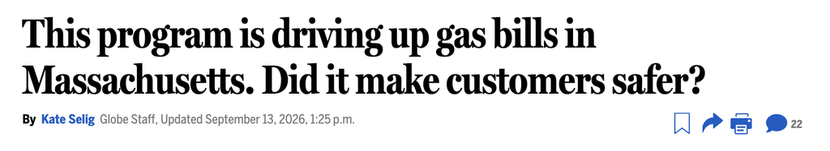

## Boston Globe case study: question

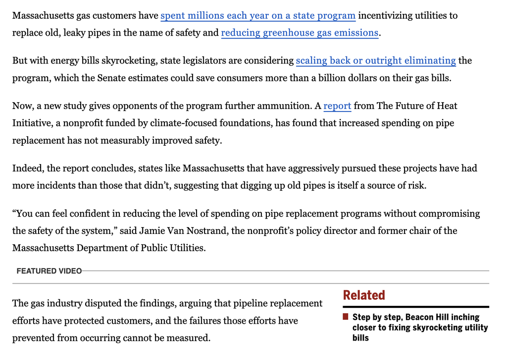

## Boston Globe case study: data

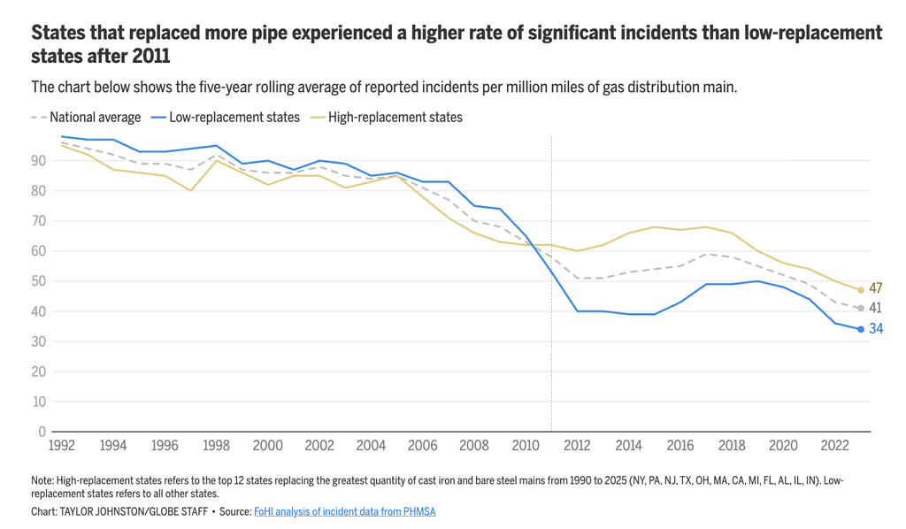

## Boston Globe case study: complementary reporting

[WBUR: “Mass. orders utilities to spend less ratepayer money on natural gas pipelines”](https://www.wbur.org/news/2025/05/01/natural-gas-system-massachusetts-gsep-dpu-climate-change)

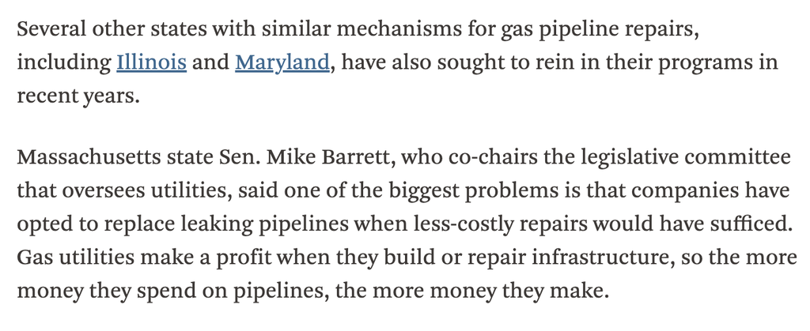

## Exercise: refine your preliminary idea list

- For one idea, propose a causal identification strategy or a test of economic theory
- Present the idea’s “bull case” and “bear case” to a classmate
- Ask your classmate to suggest another strategy or data source

## For Wednesday, September 16

- Complete the one-on-one meeting agenda in GitHub by 10:30 a.m. tomorrow